# Análisis del promedio salarial de los países

Laetitia Onofre, Fabián Calla, Mirka Prieto

25/11/2022

**PROMEDIO SALARIAL DE UN PAÍS**

**INTRODUCCIÓN**

El presente trabajo de investigación analiza los factores que pueden impactar en el promedio salarial de un país.

Existen diferentes corrientes en el pensamiento económico que difieren sobre cómo interpretar la naturaleza del salario. En primer lugar, Hayek -uno de los principales exponentes de la escuela austríaca- defendía la libertad del mercado por sobre la intervención del Estado en la economía. Esta reacción se enmarca en el contexto posterior al auge, pero también del cuestionamiento, de la eficacia del Estado de bienestar que había proliferado en la Europa del siglo XX. Para el autor, la intervención del Estado es perjudicial para el desarrollo de la economía.

En ese sentido, para Hayek, la determinación de los salarios por medios externos a los definidos dentro del mercado, es una resolución injusta y perjudicial al crecimiento económico al ser de tipo redistributivo y no impersonal (Gamonal 2016:298). Así, Hayek señalaba que “en el mundo real nadie puede saber dónde se necesita a las personas, sino sólo el mercado, que absorbe y dirige las miríadas de informaciones que poseen todos los que compran y venden en él. Y lo que precisamente hace tolerable su decisión es que no sea la opinión de una persona (como un ministro o comisario), o de un grupo de hombres identificables (como un gabinete o un politburó), sino que se deriva de unas señales impersonales dentro de un proceso que ningún individuo ni grupo puede dirigir” (Hayek 2009:91). En ese sentido, es el mercado quien debería determinar los salarios por medio de la ley de oferta y demanda dentro de los ciclos productivos de la economía.

Finalmente, el autor reconoce a los sindicatos como un factor que incrementa artificialmente los salarios junto con el desempleo y la inflación. Para Hayek, aquellos usan la “fuerza y la violencia para impedir que otra gente trabaje en los términos que trabajan” (Hayek 1985). La baja en los salarios debe verse como una consecuencia de la dismunición de demanda de personal (o el incremento artificial insostenible que provocan los sindicatos), pero como algo normal en los ciclos productivos.

En ese sentido, la situación de los obreros parados “sólo puede ser remediada eficazmente reorientando a los obreros a trabajos en los que puedan ser empleados duraderamente. En una sociedad libre, esta reorientación exige que los salarios relativos cambien para hacer menos atractiva las perspectivas en ocupaciones o industrias cuya mano de obra sea excesiva y, más atractivas, donde esté aumentando la demanda de mano de obra” (Hayek 2009:94).Esta solución es posible en una sociedad en la que los obreros son libres de escoger su trabajo. Son los incentivos económicos los que orientan esta dinámica, no la planificación estatal.

Sin embargo, la perspectiva sobre los salarios cambia si es que nos acercamos a los postulados de la teoría crítica del pensamiento económico clásico. En ese sentido, Marx entiende a los salarios como “la parte de la mercancía ya existente, con la que el capitalista compra una determinada cantidad de fuerza de trabajo productiva […] La fuerza de trabajo es, pues, una mercancía que su propietario, el obrero asalariado, vende al capital. ¿Para qué la vende? Para vivir” (Marx 2019:3). El salario no sería el resultado de la oferta y la demanda sobre el precio del trabajo del trabajador, sino la mercancía que el capitalista intercambia con el trabajador. Este intercambio es formalmente libre en tanto es el trabajador quien pone a la venta su fuerza de trabajo. Sin embargo, la libertad formal termina en tanto la obligación surge de la necesidad de vivir del obrero, situacion relacionada con la acumulación originaria: el obrero no es dueño de los medios de producción a partir de un proceso histórico violento de arrebato de tierras, medios de vida y marginación social.

Por ello, para Marx, la variación en los salarios no depende en última instancia de una ley estática, ahistórica y neutral como la oferta y la demanda de forma mecánica. Se trata de un intercambio forzoso de mercancías no equivalentes entre sí. La relación laboral capitalista implica el pago por la fuerza de trabajo y la entrega del trabajador (como cualquier otra mercancía), pero la mercancía que entrega el trabajador difiere cualitativamente de cualquier otra en tanto es la única mercancía que puede crear algo nuevo. Sin embargo, eso “nuevo”, junto con la inteligencia y la creatividad del trabajador, no le pertenece. En tanto conforma una nueva mercancía, esta pasa a dominarlo en tanto otros trabajadores deben consumir el resultado del primer trabajo para sobrevivir.

Esto tiene una última implicancia, el trabajador debe recibir lo necesario para poder consumir las mercancías que otros trabajadores producen para vivir, pero más importante aún, para volver a trabajar al día siguiente.

Los límites de ambas perspectivas económcias pueden encontrarse en su aplicación en el ambito geográfico en el que se aplican. Hayek escribía muchas veces desde la realidad anglosajona europea. En ella, se desarrolló un Estado de bienestar que gozó por mucho tiempo de popularidad y resultados aceptables para su población, pero que decae en buena medida por factores externos como la crisis del petróleo.

Tal situación no se ha dado en América Latina y hoy los sindicatos tienen poco peso en el ámbito político. Al mismo tiempo, existen países como Perú que tienen una economía informal mucho más grande que la formal y en la que la ausencia del Estado no ha traído el progreso que las teorías más cercanas a la libertad empresarial auguraron.

Por su lado, Marx encontró su límite al dejar de lado las realidades de los países menos industrializados y de mayor peso campesino. Si bien Marx y Engels acusaron la desigualdad interna dentro del propio proletariado en términos de género y el impacto sobre las mujeres, su desarollo teórico quedó en deuda pues no conforma una variable con un desarrollo igual de profundo en su teoría.

Por ello, exploramos distintos datos en países alrededor del mundo para acercarnos a la presición sobre la naturaleza real del salario. Se sostiene que los factores económicos y sociales como inflación, brecha de pobreza; salario mínimo; indice de costo de vida; la tasa de alfabetización, el promedio de horas semanales y las mujeres que trabajan, son relevantes para esta investigación.

**REGRESIÓN LINEAL**

Indice de Costo de Vida, Inflación y Participación de las mujeres en el trabajo

```
##
## Call:
## lm(formula = PS ~ ICV + INF + MT, data = BDfinal)
##
## Residuals:
##      Min       1Q   Median       3Q      Max
## -1809.04  -461.00   -27.06   436.30  1690.12
##
## Coefficients:
##             Estimate Std. Error t value Pr(>|t|)
## (Intercept)  639.949    284.359   2.250 0.027163 *
## ICV           20.662      2.137   9.669 4.29e-15 ***
## INF          -36.800      9.762  -3.770 0.000312 ***
## MT            -3.782      5.092  -0.743 0.459782
## ---
## Signif. codes:  0 '***' 0.001 '**' 0.01 '*' 0.05 '.' 0.1 ' ' 1
##
## Residual standard error: 672.4 on 80 degrees of freedom
## Multiple R-squared:  0.5611, Adjusted R-squared:  0.5446
## F-statistic: 34.09 on 3 and 80 DF,  p-value: 2.705e-14
```

Interpretación:

Las variables que son significativas son la del Indice de Costo de Vida (ICV) y la Inflación (INF) ya que muestran resultados menores a 0.05. Es decir, es muy poco probable que no tengan efecto sobre la dependiente. Además, se observa que la varianza explicada es del 54%.

Nos interesa anotar que el Indice de Costo de Vida está afectando al promedio salarial en tanto que el aumento en un punto del ICV aumenta en 20.662 dólares el promedio. Esto está relacionado con la necesidad de asegurar la supervivencia del trabajador y la venta de su trabajo.

Vemos que el salario podría estar aumentando a razón de las necesidades de supervivencia del trabajador y no tanto a razón del valor de su fuerza de trabajo en sí misma. La oferta y demanda de trabajo estaría perdiendo peso en esta explicación en tanto otro factor del mercado (ICV e inflación) inciden en el salario percibido.

Taza de alfabetización, Salario mínimo y Porcentaje de brecha de pobreza

```
##
## Call:
## lm(formula = PS ~ Tasa_alfabetizacion + salario_min + brecha,
##     data = BDfinal)
##
## Residuals:
##      Min       1Q   Median       3Q      Max
## -1274.94  -277.25   -50.16   195.91  2243.62
##
## Coefficients:
##                       Estimate Std. Error t value Pr(>|t|)
## (Intercept)         -752.29535  405.31015  -1.856   0.0671 .
## Tasa_alfabetizacion   19.35308    4.49295   4.307 4.65e-05 ***
## salario_min            1.08938    0.09005  12.098  < 2e-16 ***
## brecha                 5.99144    9.64438   0.621   0.5362
## ---
## Signif. codes:  0 '***' 0.001 '**' 0.01 '*' 0.05 '.' 0.1 ' ' 1
##
## Residual standard error: 517.7 on 80 degrees of freedom
## Multiple R-squared:  0.7398, Adjusted R-squared:  0.7301
## F-statistic: 75.82 on 3 and 80 DF,  p-value: < 2.2e-16
```

Interpretación:

Segun el p-valor, este es un modelo válido. Se explica en el 73% y exhibe dos valores que influyen significativamente sobre la dependiente. El aumento en un punto de la tasa de alfabetización, incrementa en 19.35 dólares el promedio salarial. Asimismo, el aumento en un punto del salario mínimo, aumenta en un punto el promedio salarial.

Nos interesa anotar que un indicador relacionado con la educación (alfabetización) está incrementnado en 19.35 dolares el promedio salarial. Esto podría estar relacionado con la mano de obra especializada, la cual puede estar incrementando el costo de mano de obra pero, al mismo tiempo, incrementando las desigualdades sociales pues ese aumento se daría solo para esas personas.

Sabemos que la producción actual se sostiene con un alto grado de división del trabajo. Para Marx, este concepto tenía mucha importancia para el análisis del modo de producción capitalista. El autor señalaba que la división del trabajo conduce dentro de las naciones a la separación del trabajo industrial y del campo (separación ciudad/campo) y a la oposición de sus intereses.

El desarrollo ulterior lleva a la separación del trabajo industrial del comercial. Además, la división del trabajo trae consigo la creación de distintas secciones determinadas por la rama en la que trabajan y cuya posición respecto a otras depende de la manera en cómo se da el trabajo industrial, comercial y agrícola (estamentos, clases, esclavitud) (Marx y Engels 1972: 41). En consecuencia, “las relaciones personales se convierten necesariamente en relaciones de clase y se fijan como tales” (Marx y Engels 1972: 42). En esa separación de la calidad y trabajo de la mano obrera, la mano de obra calificada estaría ganando más que la fuerza de trabajo bruta del proletario carente de educación. Para Hyek, esta diferencia se explicaría por la competencia en el mercado. Para Marx, esta diferencia es consecuencia de la división del trabajo y la consecuente especialización que se requiere y escasea en relación a la masa no educada, personas que solo cuentan con sus brazos y su fuerza para vender.

Promedio de horas semanales, Convenios colectivos, Trabajo mayor a las 8 horas diarias

```
##
## Call:
## lm(formula = PS ~ horassemana + negocole + explotacion, data = BDfinal)
##
## Residuals:
##     Min      1Q  Median      3Q     Max
## -1697.1  -617.2  -162.9   412.4  2961.2
##
## Coefficients:
##             Estimate Std. Error t value Pr(>|t|)
## (Intercept) 2134.030   1261.249   1.692   0.0945 .
## horassemana  -12.065     34.069  -0.354   0.7242
## negocole      10.402      4.552   2.285   0.0249 *
## explotacion  -15.926      9.886  -1.611   0.1111
## ---
## Signif. codes:  0 '***' 0.001 '**' 0.01 '*' 0.05 '.' 0.1 ' ' 1
##
## Residual standard error: 919.1 on 80 degrees of freedom
## Multiple R-squared:  0.1799, Adjusted R-squared:  0.1491
## F-statistic: 5.848 on 3 and 80 DF,  p-value: 0.001156
```

COMPARACIÓN DE LOS 3 MODELOS

```
##
## ==============================================================
##                                     Dependent variable:
##                               --------------------------------
##                                              PS
##                                  (1)        (2)        (3)
## --------------------------------------------------------------
## ICV                           20.662***
##                                (2.137)
##
## INF                           -36.800***
##                                (9.762)
##
## MT                              -3.782
##                                (5.092)
##
## Tasa_alfabetizacion                      19.353***
##                                           (4.493)
##
## salario_min                              1.089***
##                                           (0.090)
##
## brecha                                     5.991
##                                           (9.644)
##
## horassemana                                          -12.065
##                                                     (34.069)
##
## negocole                                            10.402**
##                                                      (4.552)
##
## explotacion                                          -15.926
##                                                      (9.886)
##
## Constant                      639.949**  -752.295* 2,134.030*
##                               (284.359)  (405.310) (1,261.249)
##
## --------------------------------------------------------------
## Observations                      84        84         84
## R2                              0.561      0.740      0.180
## Adjusted R2                     0.545      0.730      0.149
## Residual Std. Error (df = 80)  672.391    517.680    919.110
## F Statistic (df = 3; 80)      34.086***  75.825***  5.848***
## ==============================================================
## Note:                              *p<0.1; **p<0.05; ***p<0.01
```

En comparación, vemos que el modelo 2 está explicando mejor la dependiente con un 73% de varianza explciada en el r2 ajustado.

Regresión con las 9 variables independientes:

```
##
## Call:
## lm(formula = PS ~ horassemana + negocole + explotacion + Tasa_alfabetizacion +
##     salario_min + brecha + ICV + INF + MT, data = BDfinal)
##
## Residuals:
##      Min       1Q   Median       3Q      Max
## -1102.86  -279.26   -60.26   245.70  1860.71
##
## Coefficients:
##                       Estimate Std. Error t value Pr(>|t|)
## (Intercept)         -3516.0649  1054.5512  -3.334  0.00134 **
## horassemana            60.4001    23.4787   2.573  0.01210 *
## negocole               -2.0972     2.6834  -0.782  0.43697
## explotacion            -1.4764     6.3991  -0.231  0.81817
## Tasa_alfabetizacion    21.0621     5.0238   4.192 7.56e-05 ***
## salario_min             1.1586     0.1755   6.603 5.34e-09 ***
## brecha                 13.3433    10.7846   1.237  0.21990
## ICV                     1.7484     3.4296   0.510  0.61171
## INF                    -9.0102     8.4043  -1.072  0.28716
## MT                      3.9479     4.7903   0.824  0.41250
## ---
## Signif. codes:  0 '***' 0.001 '**' 0.01 '*' 0.05 '.' 0.1 ' ' 1
##
## Residual standard error: 501.7 on 74 degrees of freedom
## Multiple R-squared:  0.774,  Adjusted R-squared:  0.7465
## F-statistic: 28.16 on 9 and 74 DF,  p-value: < 2.2e-16
```

Nos interesa anotar la persistencia de la educación en su influencia sobre el salario. Mientras que para Hayek esto sería resultado de la libre competencia entre trabajadores. Para Marx, esta diferencia se explica por la división del trabajo que requiere de ambos tipos de mano de obra, creando una separación dentro de la propia clase sustentada por su posición en la estrutura productiva. Se trata de la división del trabajo manual e intelectual que trae consigo la reproducción de desigualdades sociales.

**ANÁLISIS FACTORIAL EXPLORATORIO**

- Calculamos la matriz de correlación:

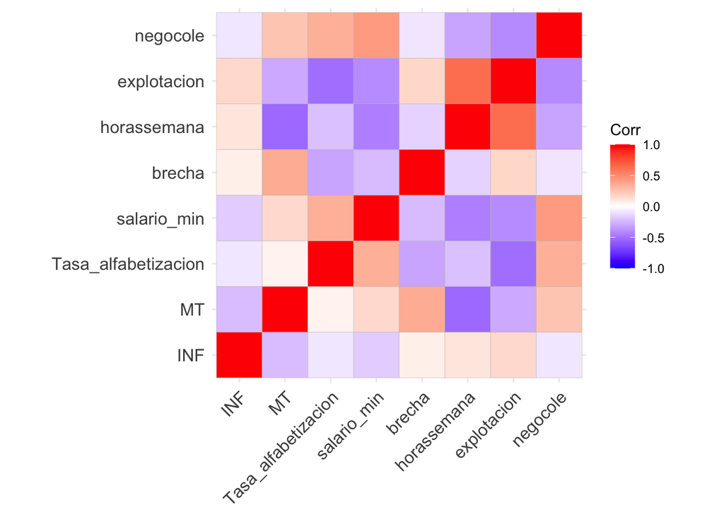

Interpretación del modelo:

En el gráfico de correlación, “horassemanas” y “explotación” son las que están más correlacionadas. Mientras que una hace referencia al promedio del tiempo de trabajo, la otra hace referencia a las horas trabajadas fuera de lo permtiido por la ley.

Sin embargo, hay variables como “salario mínimo” con “negociación colectiva” que tienen mayor nivel de correlación en relación al resto; esta relación, según Hayek, tendría que ver con un aumento artificial de los salarios. Aunque podemos pensar que esto sería beneficioso para la calidad de vida del trabajador, el autor señala que esto afecta al desempleo en tanto reduce las posibilidades del empleador para contratar personal a ese precio.

- Veremos si se puede factorizar

```
## Kaiser-Meyer-Olkin factor adequacy
## Call: psych::KMO(r = corL)
## Overall MSA =  0.67
## MSA for each item =
##                 INF                  MT Tasa_alfabetizacion         salario_min
##                0.55                0.65                0.73                0.71
##              brecha         horassemana         explotacion            negocole
##                0.55                0.62                0.68                0.79
```

El overall es 0.67 por lo cual, todavía estamos dentro del valor adecuado para un análisis factorial.

- Vemos si la matriz de correlaciones es adecuada

  *Calculamos la Matriz identidad

```
## [1] FALSE
```

- Calculamos la Matriz singular

```
## [1] FALSE
```

Vemos que ambos resultado son False por lo que podemos continuar con el trabajo

- Aquí vemos en cuántos factores se puede redimensionar la data

```
## Parallel analysis suggests that the number of factors =  2  and the number of components =  NA
```

- Ahora redimensionamos a un menor número de factores:

```
##
## Loadings:
##                     MR1    MR2
## INF                 -0.202
## MT                   0.333  0.668
## Tasa_alfabetizacion  0.590 -0.241
## salario_min          0.624
## brecha              -0.278  0.670
## horassemana         -0.658 -0.487
## explotacion         -0.788
## negocole             0.549
##
##                  MR1   MR2
## SS loadings    2.323 1.205
## Proportion Var 0.290 0.151
## Cumulative Var 0.290 0.441
```

```
##
## Loadings:
##                     MR1    MR2
## INF
## MT                          0.668
## Tasa_alfabetizacion  0.590
## salario_min          0.624
## brecha                      0.670
## horassemana         -0.658
## explotacion         -0.788
## negocole             0.549
##
##                  MR1   MR2
## SS loadings    2.323 1.205
## Proportion Var 0.290 0.151
## Cumulative Var 0.290 0.441
```

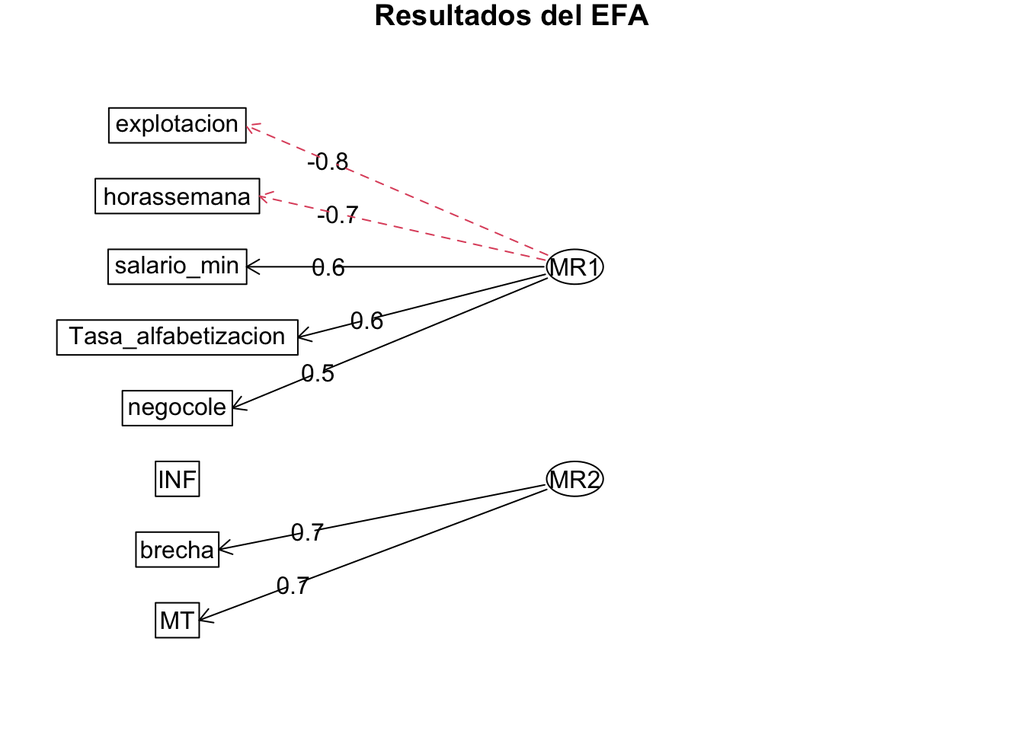

Notamos que casi todas superan el 0.5

El salario mínimo, la tasa de alfabetización y la negociación colectiva están relacionadas. Estas variables tienen que ver con la educación y la capacidad de organización de los trabajadores.

Por otro lado, la brecha de pobreza y trabajo de la mujer pueden relacionarse con el hecho que se trata de variables relacionadas con desigualdades sociales estructurales e históricas en los que media la amrginación y las oportunidades laborales desiguales.

```
##
## Loadings:
##                     MR1    MR2
## INF
## MT                          0.668
## Tasa_alfabetizacion  0.590
## salario_min          0.624
## brecha                      0.670
## horassemana         -0.658
## explotacion         -0.788
## negocole             0.549
##
##                  MR1   MR2
## SS loadings    2.323 1.205
## Proportion Var 0.290 0.151
## Cumulative Var 0.290 0.441
```

La varianza acumulada de 0.44; esto significa que hemos recuperado el 44% de información. Todo proceso de síntesis pierde información, pero se queda con lo importante.

- Evaluamos qué variables aportaron más a los factores

Comunalidad:

```
##                 INF            negocole         salario_min Tasa_alfabetizacion
##          0.04620181          0.30270103          0.39107572          0.40630964
##              brecha                  MT         explotacion         horassemana
##          0.52648429          0.55766883          0.62780209          0.66976950
```

Evaluación de variables que aportan más al modelo

|  | x |
| --- | --- |
| INF | 0.0462018 |
| MT | 0.5576688 |
| Tasa_alfabetizacion | 0.4063096 |
| salario_min | 0.3910757 |
| brecha | 0.5264843 |
| horassemana | 0.6697695 |
| explotacion | 0.6278021 |
| negocole | 0.3027010 |

**En este caso, vemos que el que más aporta es el promedio de horas semanales** el que menos aporta es inflación.

- ¿Qué variables contribuyen a más de un factor?

Complejidad:

```
##         salario_min            negocole         explotacion                 INF
##            1.007035            1.012074            1.020536            1.259946
## Tasa_alfabetizacion              brecha                  MT         horassemana
##            1.323420            1.334887            1.468771            1.842221
```

Complejidad

|  | x |
| --- | --- |
| INF | 1.259946 |
| MT | 1.468771 |
| Tasa_alfabetizacion | 1.323420 |
| salario_min | 1.007035 |
| brecha | 1.334887 |
| horassemana | 1.842221 |
| explotacion | 1.020536 |
| negocole | 1.012074 |

- Valores proyectados (resumen)

```
##           MR1         MR2
## 1  0.05020542 -0.32941143
## 2  1.39207487  0.18404290
## 3 -0.79346723 -1.21336109
## 4  0.30826196  0.08167107
## 5  0.01622238 -0.41590880
## 6  1.45628303  0.37622596
```

**CONGLOMERADOS**

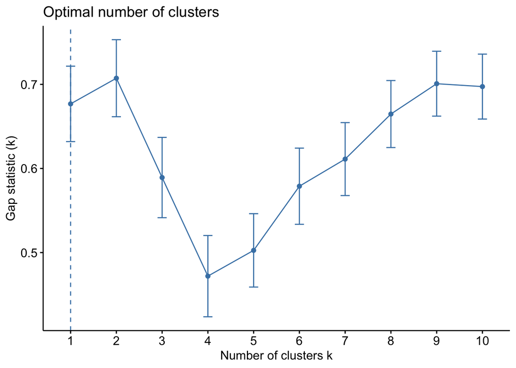

A pesar de que el gráfico indica que debemos hacer solo 1 cluster, se ha decidido trabajar con tres grupos para una mejor comparación.

PAM

```
##                ICV   INF    MT Tasa_alfabetizacion salario_min brecha
## Albania     33.600  1.80 50.73            98.14115       236.7    0.0
## Alemania   111.300  1.75 56.84            99.00000      1747.5    0.0
## Argelia     36.100  2.70 15.68            81.40784       226.8    0.2
## Argentina  160.765 47.65 50.01            99.00387       293.2    0.3
## Armenia     40.800  1.90 42.66            99.73607       114.5    0.1
## Australia  142.300  1.79 61.06            99.00000      2229.9    0.4
## Azerbaiyan  35.900  2.30 60.37            99.79598       147.1    0.0
## Bangladesh  47.100  5.44 34.87            74.68446        17.8    2.4
## Belgica    116.900  2.20 49.84            99.00000      1784.2    0.1
## Benin       45.200  0.97 69.33            42.36240        64.0    4.8
## Bolivia     43.700  1.90 68.28            92.45508       309.3    0.6
## Brasil      56.600  3.75 49.11            93.22750       253.0    2.1
## Bulgaria    37.500  2.31 49.14            98.35245       320.5    0.3
## Canada     127.400  2.05 60.80            99.00000      1456.9    0.1
## Chile       75.900  2.14 44.17            96.40228       429.6    0.2
##            horassemana pam
## Albania          41.21   1
## Alemania         34.17   2
## Argelia          43.70   3
## Argentina        35.13   2
## Armenia          39.85   1
## Australia        33.23   2
## Azerbaiyan       36.88   1
## Bangladesh       46.93   3
## Belgica          35.71   2
## Benin            40.36   1
## Bolivia          40.44   1
## Brasil           35.11   1
## Bulgaria         39.42   1
## Canada           32.10   2
## Chile            34.63   1
```

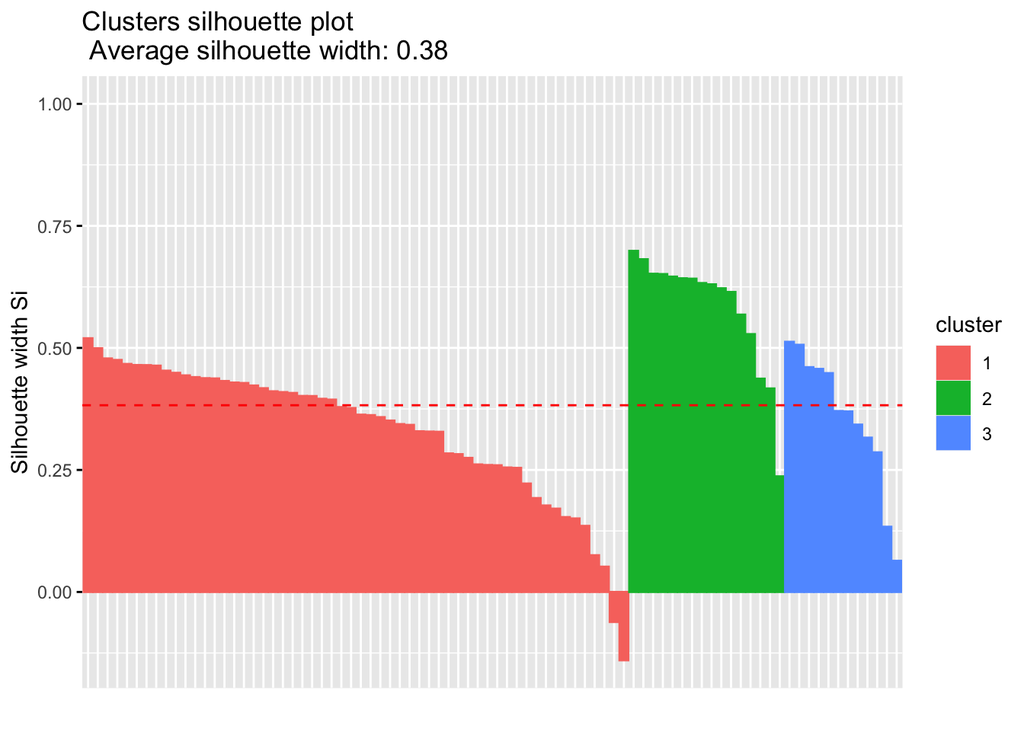

Veamos cuáles son los países que están mal clusterizados.

```
## [1] "Mauritania" "Portugal"
```

En este caso los países mal clusterizados son Mauritania y Portugal.

```
##   pam       ICV      INF       MT Tasa_alfabetizacion salario_min    brecha
## 1   1  50.11250 3.160893 54.24286            90.01144    312.2804 3.0196429
## 2   2 130.12906 4.503750 56.29750            98.88789   1722.0063 0.1937500
## 3   3  46.34167 9.370000 21.67750            82.23487    218.4333 0.5083333
##   horassemana
## 1    39.11214
## 2    35.48562
## 3    45.11167
```

Grafica de PAM

```
##                      [,1]         [,2]
## Albania       -0.05299359  0.022371596
## Alemania       0.27987076 -0.006343377
## Argelia       -0.22799806  0.130050316
## Argentina      0.24000118  0.108409048
## Armenia       -0.05520285  0.030086853
## Australia      0.35139384 -0.037844563
## Azerbaiyan     0.01693771 -0.077157875
## Bangladesh    -0.24956793  0.069450225
## Belgica        0.26685006  0.047590279
## Benin         -0.17814522 -0.217633905
## Bolivia       -0.05051106 -0.076762053
## Brasil         0.01598935 -0.030280395
## Bulgaria      -0.02762397  0.008487098
## Canada         0.30403772 -0.040182455
## Chile          0.08072102  0.037450973
## China         -0.01515894  0.071215335
## Colombia      -0.01972039 -0.020762308
## Corea del Sur  0.19685290  0.047638013
## Costa Rica     0.02304321 -0.000851865
## Croacia        0.01141044  0.019368222
```

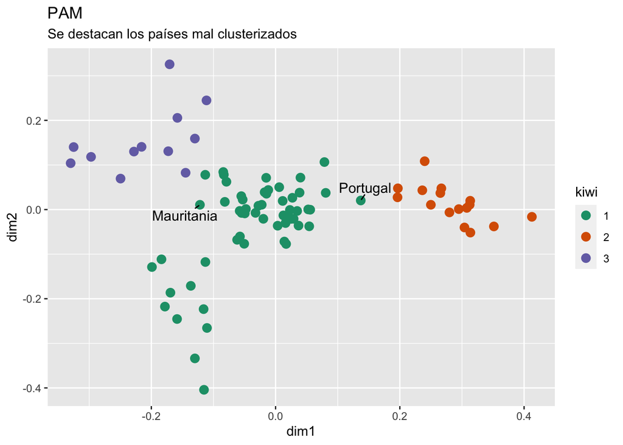

[Tratamos de demostrar en un mapa los grupos formados por países según la clusterización realizada. Sin embargo, no pudo ser posible debido a que el shapefile se encontraba en inglés y no encontramos uno en español que tenga los nombres de los países para hacer merge]

**Conclusiones**

Finalmente, los resultados del EFA relacionaron a las variables en dos grupos con caracteristicas similares. El MR1 tiene que ver con la educación del trabajador y su capacidad de organización en sindicatos. Estas caracterísitcas son adecuadas para el desarrollo de una conciencia de clase que le permita al trabajador al menos mejorar o mantener sus condiciones laborales.

La crítica a la actualidad de las organizaciones sindicales pasa por el hecho de que sus direcciones son “burocraticas y [de] compromiso con el Estado y con quienes son dueños de los medios de producción” (Gónzales 2021: 13). En economías informales como la peruana, los trabajadores que pueden sindicalizarse son los menos, o mejor dicho, los privilegiados.

Este fenómeno, evidenciado en las desigualdades internas dentro de la clase trabajadora, como en su educación en tanto mejora en la calidad de su mercancía (fuerza de trabajo), nos permite decir que la integración de una sola clase de trabajadores es virtualmente imposible. Para Rosa Luxemburgo, la huelga y la organización sindical podían ser espacios de aprendizaje y desarrollo de conciencia de clase. Este espacio en América Latina ha tenido un desarrollo accidentado y de periodos de clientelismo con los gobiernos de turno.

Además, su base numérica ha sido mermada por la flexibilización de leyes, informalidad y la propia ideología. Por ello, si se desea generar nuevos espacios de resistencia, la organización sindical para la negociación colectiva parece ser un medio inadecuado y poco actualizado, no sostiene un imapcto real sobre el salario de los trabajadores. Deben buscarse nuevas formas que incluyan a la variable de género y las desigualdades de desarrollo internas del proletariado.

Bibliografía:

- Gamonal Contreras, Sergio. (2017). Hayek y los sindicatos: Una visión crítica. Ius et Praxis, 23(2), 295-326. https://dx.doi.org/10.4067/S0718-00122017000200295
- Hayek, Friedrich A. (2009): “El Paro y los Sindicatos en los años ochenta (El falseamiento de los precios relativos por el monopolio del mercado de trabajo)”, en: Sindicatos, ¿Para Qué?, publicado originalmente en inglés en 1980 (Madrid, Unión Editorial), pp. 41-103.
- Marx, K., Engels, F., & Roces, W. (1972). La ideología alemana: crítica de la novísima filosofía alemana en las personas de sus representantes Feuerbach, B. Bauer y Stirner y del socialismo alemán en las de sus diferentes profetas. Grijalbo.
- Marx, K. (2019). Trabajo asalariado y capital (Vol. 1). Editorial Verbum.